# Spotify

### Description of the Dataset:

```python
import warnings
warnings.filterwarnings("ignore")
```

```python
#Load the import Labraries
import pandas as pd
import numpy as np
import matplotlib.pyplot as plt
import seaborn as sns
```

```python
df=pd.read_csv("Spotify.csv")
df.head(5)
```

|  | Artist | Track Name | Popularity | Duration (ms) | Track ID |
| --- | --- | --- | --- | --- | --- |
| 0 | Drake | Rich Baby Daddy (feat. Sexyy Red & SZA) | 92 | 319191 | 1yeB8MUNeLo9Ek1UEpsyz6 |
| 1 | Drake | One Dance | 91 | 173986 | 1zi7xx7UVEFkmKfv06H8x0 |
| 2 | Drake | IDGAF (feat. Yeat) | 90 | 260111 | 2YSzYUF3jWqb9YP9VXmpjE |
| 3 | Drake | First Person Shooter (feat. J. Cole) | 88 | 247444 | 7aqfrAY2p9BUSiupwk3svU |
| 4 | Drake | Jimmy Cooks (feat. 21 Savage) | 88 | 218364 | 3F5CgOj3wFlRv51JsHbxhe |

```python
df.columns
```

```
Index(['Artist', 'Track Name', 'Popularity', 'Duration (ms)', 'Track ID'], dtype='object')
```

# About Columns:

exploration.

1.Load the dataframe and ensure data quality by checking for missing values and duplicate rows. Handle missing values and remove duplicate rows if necessary.

```python
df.isnull().sum()
```

```
Artist           0
Track Name       0
Popularity       0
Duration (ms)    0
Track ID         0
dtype: int64
```

Their is no missing values in the DataFrame of spotify

```python
df.shape
```

```
(440, 5)
```

```python
# check the unique Artist
len(df['Artist'].unique())
```

```
115
```

```python
# Check the duplicate rows
df.duplicated().sum()

# Remove duplicates rows from the DataFrame
df= df.drop_duplicates()
```

```python
df.shape
```

```
(413, 5)
```

```python
df.duplicated().sum()
```

```
0
```

2.What is the distribution of popularity among the tracks in the dataset? Visualize it using a histogram

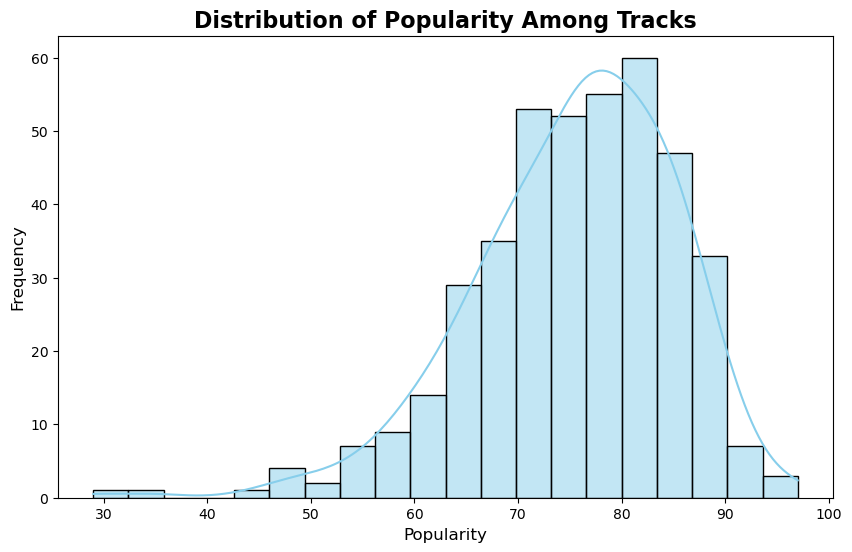

```python
# Plot the distribution of popularity
plt.figure(figsize=(10, 6))
sns.histplot(df['Popularity'], bins=20, kde=True, color='skyblue')

# Add titles and labels
plt.title('Distribution of Popularity Among Tracks', fontsize=16, fontweight='bold')
plt.xlabel('Popularity', fontsize=12)
plt.ylabel('Frequency', fontsize=12)

# Show the plot
plt.show()
```

Here are some insights based on the histogram showing the distribution of popularity among tracks:

- Normal Distribution: The distribution of popularity appears to be roughly normal, with a peak around the 80 mark. This suggests that most tracks have a popularity score in this range.
- Frequency Peaks: The highest frequency of tracks is observed in the 70-80 popularity range, indicating that a significant number of tracks are quite popular.
- Lower Popularity Scores: There are fewer tracks with popularity scores below 50, suggesting that very low popularity is less common among the dataset.
- High Popularity Scores: While there are tracks with popularity scores above 90, they are less frequent, indicating that extremely high popularity is achieved by fewer tracks.
- Spread of Data: The distribution shows a gradual decline in frequency as popularity scores move away from the peak, indicating that while many tracks are popular, fewer achieve very high popularity.
- Outliers: There are some outliers on the lower end (below 40), but they are minimal compared to the overall distribution.

Overall, the data suggests that most tracks tend to have moderate to high popularity, with a notable concentration around the 70-80 range.

3.Is there any relationship between the popularity and the duration of tracks? Explore this using a scatter plot.

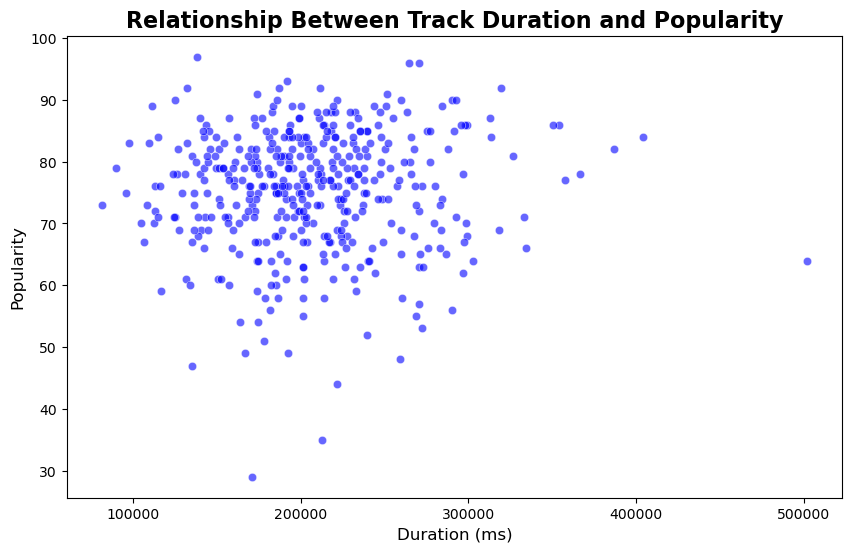

```python
#Plot the relationship between popularity and duration
plt.figure(figsize=(10, 6))
sns.scatterplot(x='Duration (ms)', y='Popularity', data=df, color='blue', alpha=0.6)

# Add titles and labels
plt.title('Relationship Between Track Duration and Popularity', fontsize=16, fontweight='bold')
plt.xlabel('Duration (ms)', fontsize=12)
plt.ylabel('Popularity', fontsize=12)

# Show the plot
plt.show()
```

4.Which artist has the highest number of tracks in the dataset? Display the count of tracks for each artist using a countplot.

```
The artist with the highest number of tracks is Drake with 17 tracks.
```

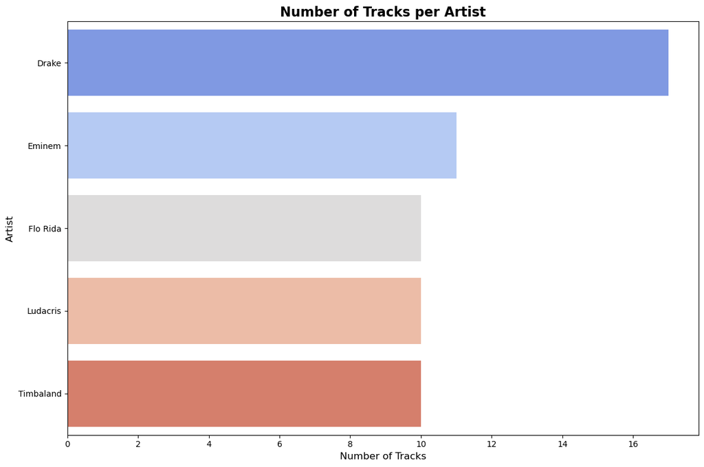

```python
# Count the number of tracks for each artist
artist_counts = df['Artist'].value_counts().head(5)

# Find the artist with the highest number of tracks
top_artist = artist_counts.idxmax()
top_tracks = artist_counts.max()

print(f"The artist with the highest number of tracks is {top_artist} with {top_tracks} tracks.")

# Plot the count of tracks for each artist using a countplot
plt.figure(figsize=(12, 8))
sns.countplot(y='Artist', data=df, order=artist_counts.index, palette='coolwarm')

# Add title and labels
plt.title('Number of Tracks per Artist', fontsize=16, fontweight='bold')
plt.xlabel('Number of Tracks', fontsize=12)
plt.ylabel('Artist', fontsize=12)

# Show the plot
plt.tight_layout()
plt.show()
```

5.What are the top 5 least popular tracks in the dataset? Provide the artist name and track name for each.

```python
# Sort the dataset by the 'Popularity' column in ascending order to get the least popular tracks
least_popular_tracks = df[['Artist', 'Track Name', 'Popularity']].sort_values(by='Popularity').head(5)

# Display the top 5 least popular tracks (Artist and Track Name)
print("Top 5 Least Popular Tracks:")
print(least_popular_tracks)
```

```
Top 5 Least Popular Tracks:
             Artist                     Track Name  Popularity
207          Pressa  Attachments (feat. Coi Leray)          29
231   Justin Bieber                     Intentions          35
413  French Montana                Splash Brothers          44
225        Lil Baby                  On Me - Remix          47
407     Wyclef Jean      911 (feat. Mary J. Blige)          48
```

6.Among the top 5 most popular artists, which artist has the highest popularity on average? Calculate and display the average popularity for each artist.

```python
#Group by 'Artist' and calculate the average 'Popularity'
artist_avg_popularity = df.groupby('Artist')['Popularity'].mean().reset_index()

# Round the 'Popularity' values to two decimal places
artist_avg_popularity['Popularity'] = artist_avg_popularity['Popularity'].round(2)

# Sort by 'Popularity' in descending order to get the most popular artists
top_5_artists = artist_avg_popularity.sort_values(by='Popularity', ascending=False).head(5)

# Display the top 5 artists and their average popularity
print("Top 5 Most Popular Artists by Average Popularity:")
print(top_5_artists)
```

```
Top 5 Most Popular Artists by Average Popularity:
           Artist  Popularity
113         cassö       92.00
104        Trueno       89.00
24   David Guetta       87.00
103  Travis Scott       86.56
114            ¥$       85.10
```

7.For the top 5 most popular artists, what are their most popular tracks? List the track name for each artist.

```python
# Group by 'Artist' and calculate the average 'Popularity'
artist_avg_popularity = df.groupby('Artist')['Popularity'].mean().reset_index()

# Sort by 'Popularity' in descending order to get the most popular artists
top_5_artists = artist_avg_popularity.sort_values(by='Popularity', ascending=False).head(5)['Artist']

# Filter the dataset for only the top 5 artists
top_5_artists_df = df[df['Artist'].isin(top_5_artists)]

# Find the most popular track for each of the top 5 artists
most_popular_tracks = top_5_artists_df.loc[top_5_artists_df.groupby('Artist')['Popularity'].idxmax()]

# Select only the 'Artist' and 'Track Name' columns
most_popular_tracks = most_popular_tracks[['Artist', 'Track Name', 'Popularity']].sort_values(by='Popularity', ascending=False)

# Display the result
print("Most Popular Tracks for the Top 5 Most Popular Artists:")
print(most_popular_tracks)
```

```
Most Popular Tracks for the Top 5 Most Popular Artists:
           Artist                    Track Name  Popularity
260            ¥$                      CARNIVAL          96
30   Travis Scott    FE!N (feat. Playboi Carti)          93
140         cassö                         Prada          92
241        Trueno  Mamichula - con Nicki Nicole          89
200  David Guetta            Baby Don't Hurt Me          87
```

```python
df.columns
```

```
Index(['Artist', 'Track Name', 'Popularity', 'Duration (ms)', 'Track ID'], dtype='object')
```

8.Visualize relationships between multiple numerical variables simultaneously using a pair plot

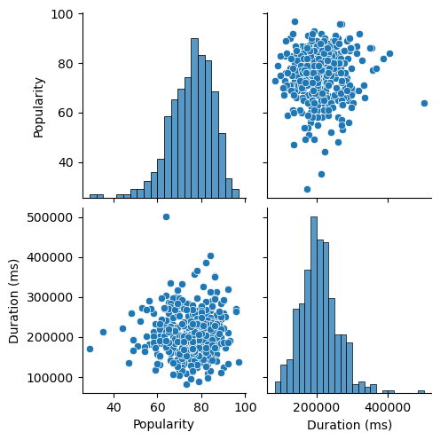

```python
# Select numerical columns for pair plot
numerical_cols= ['Popularity','Duration (ms)']

#create a pair plot
sns.pairplot(df[numerical_cols])
```

9.Does the duration of tracks vary significantly across different artists? Explore this visually using a box plot or violin plot.

Using a Box Plot

- A box plot shows the distribution of track durations across different artists, including median, quartiles, and potential outliers.

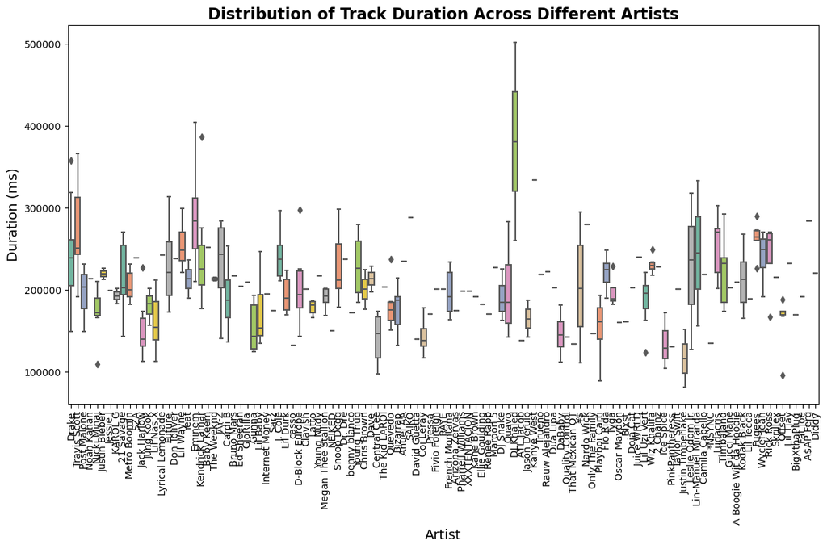

```python
# Create a box plot to visualize the distribution of track durations across different artists
plt.figure(figsize=(12, 8))
sns.boxplot(x='Artist', y='Duration (ms)', data=df, palette='Set2')

# Add title and labels
plt.title('Distribution of Track Duration Across Different Artists', fontsize=16, fontweight='bold')
plt.xlabel('Artist', fontsize=14)
plt.ylabel('Duration (ms)', fontsize=14)
plt.xticks(rotation=90)  # Rotate x-axis labels if needed

plt.tight_layout()
plt.show()
```

Using a Violin Plot

- A violin plot provides a combination of a box plot and a kernel density plot, showing the distribution of track durations and its density across different artists.

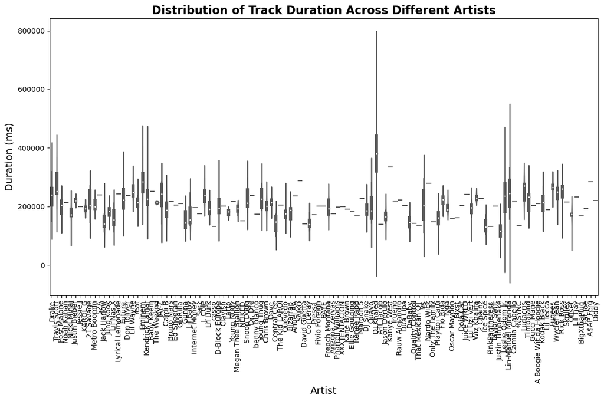

```python
# Create a violin plot to visualize the distribution of track durations across different artists
plt.figure(figsize=(12, 8))
sns.violinplot(x='Artist', y='Duration (ms)', data=df, palette='Set2')

# Add title and labels
plt.title('Distribution of Track Duration Across Different Artists', fontsize=16, fontweight='bold')
plt.xlabel('Artist', fontsize=14)
plt.ylabel('Duration (ms)', fontsize=14)
plt.xticks(rotation=90)  # Rotate x-axis labels if needed

plt.tight_layout()
plt.show()
```

10.How does the distribution of track popularity vary for different artists? Visualize this using a swarm plot or a violin plot.

Using a Swarm Plot

- A swarm plot shows individual data points and their distribution, providing a clear view of how popularity scores are distributed for each artist.

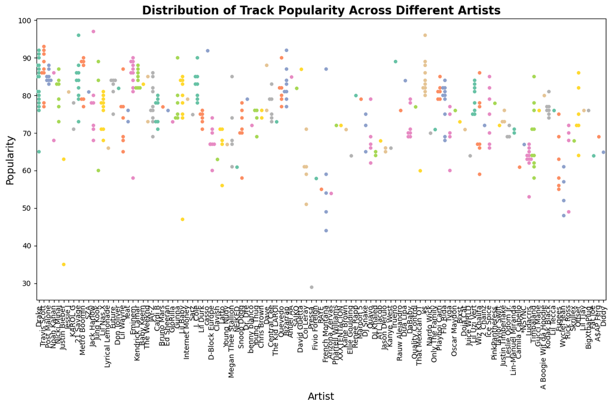

```python
# Create a swarm plot to visualize the distribution of track popularity across different artists
plt.figure(figsize=(12, 8))
sns.swarmplot(x='Artist', y='Popularity', data=df, palette='Set2')

# Add title and labels
plt.title('Distribution of Track Popularity Across Different Artists', fontsize=16, fontweight='bold')
plt.xlabel('Artist', fontsize=14)
plt.ylabel('Popularity', fontsize=14)
plt.xticks(rotation=90)  # Rotate x-axis labels if needed

plt.tight_layout()
plt.show()
```

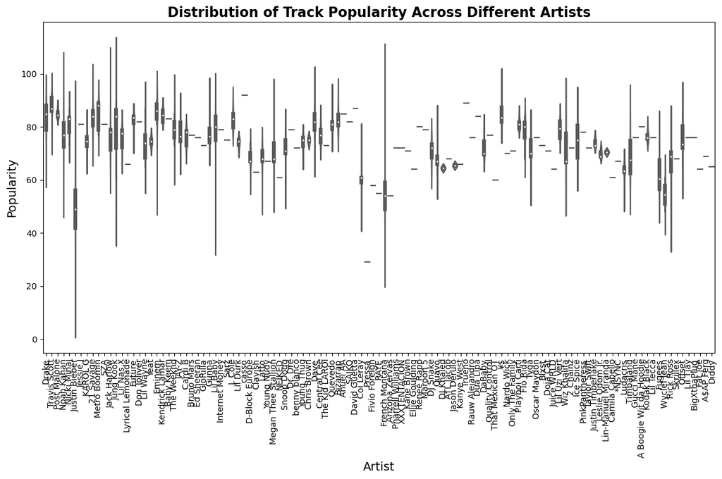

```python
# Create a violin plot to visualize the distribution of track popularity across different artists
plt.figure(figsize=(12, 8))
sns.violinplot(x='Artist', y='Popularity', data=df, palette='Set2')

# Add title and labels
plt.title('Distribution of Track Popularity Across Different Artists', fontsize=16, fontweight='bold')
plt.xlabel('Artist', fontsize=14)
plt.ylabel('Popularity', fontsize=14)
plt.xticks(rotation=90)  # Rotate x-axis labels if needed

plt.tight_layout()
plt.show()
```